# Multivariate Regression Analysis

Ryan Taylor

08/23/2025

# Overview

This document records the methods and results of one multivariate regression analysis and a series of generalized additive models to describe regional brain volume patterns in craniosynostosis patients and normative control patients.

# Data

First we load the data for the analysis. All of the data is stored in the “Volumetric Results-8-6-2024” Excel file.

We create a clean column indicating the category of suture, which we use to examine model performance across subsets of patients.

If a patient has both left coronal and right coronal sutures, we classify them as “Bicoronal.” If they have another combination of multiple sutures, we classify them as “multiple,” and eventually exclude them. If they have no sutures, we classify them as “No suture.” Otherwise, we classify them based on the single suture they have.

We also compute the total deviation between the volume of the patient’s actual head and the volume of their personalized normative reference head. This total deviation is later used in our explanatory model to control for *overall* head shape abnormality, allowing more precise estimation of the effect of suture fusions on *regional* volumes.

```r
here::i_am("analysis/2025.06_cranio_volume_patterns.Rmd")

IMAGES_FOLDER <- here::here("analysis/Presentation Images")

# File saved in "data" folder one level above repo
cranio_raw <- read_xlsx(here::here("../data/VolumetricResults-8-6-2024.xlsx"))

# Rename for easier coding
cranio <- cranio_raw %>% clean_names() %>%
  rename(head_vol = head_volume_m_l,
         ref_head_vol = personalized_normative_reference_head_volume_m_l,
         age = age_at_image_days) %>%
  # Rename all "volume_difference" outcome variables to "vol_dev" and shorten "region"
  rename_with(.cols = matches("volume_difference"),
              ~str_replace(., "volume_difference_m_l", "vol_dev") %>%
                str_replace("region", "reg")) %>%
  # Add volume deviation across entire head
  mutate(vol_dev_head = head_vol - ref_head_vol)

# Categorize each patient separately based on sutures
# **NOTE: These are not categories used in the regression, but it is useful for plotting
# - (creating "bicoronal" / "multiple")
sut <- cranio %>% select(matches("fused")) %>%
  mutate(i = 1:n()) %>%
  pivot_longer(cols = -i) %>%
  mutate(suture = if_else(value == 1, name, NA_character_)) %>%
  group_by(i) %>%
  summarize(sutures = paste(na.omit(suture), collapse = "/")) %>%
  ungroup() %>%
  arrange(i)

# Merge suture classification into original dataset
cranio %<>%
  bind_cols(sut %>% select(sutures)) %>%
  mutate(num_sutures = rowSums(select(., matches("fused"))),
         suture_type = case_when(num_sutures == 2 &
                                   left_coronal_fused == 1 &
                                   right_coronal_fused == 1 ~ "bicoronal",
                                 num_sutures > 1 ~ "multiple",
                                 num_sutures == 0 ~ "no_suture",
                                 T ~ sutures)) %>%
  mutate(suture_type = str_remove_all(suture_type, "_fused"))
```

## Data counts

First, we summarize the data at the highest level to understand the number of images, the number of unique patients contributing images, and the number of unique patients with a suture fusion.

```r
# Summarize counts of pictures and patients
cran_summ <- cranio %>%
  summarize("Rows" = n(),
            "Unique Pictures" = n_distinct(image_identifier),
            "Unique Patients" = n_distinct(uid),
            "Craniosynostosis Patients" = n_distinct(uid[suture_type != "no_suture"])) %>%
  pivot_longer(everything(), names_to = "  ", values_to = " ")

# Print summary table
summ_kable <- kable(cran_summ, caption = "All pictures and patients") %>%
  kable_styling(full_width = F)

summ_kable
```

All pictures and patients

| Rows | 2626 |
| --- | --- |
| Unique Pictures | 2626 |
| Unique Patients | 2464 |
| Craniosynostosis Patients | 746 |

## Data cleaning

Next, we select the subset of data that will be used for our analyses. There are some rare suture fusion types that we should exclude to reduce the variability of the data. We exclude images with multiple sutures or lambdoid sutures. Additionally, a small number of patients’ sex or age is missing; since these are important controls, we exclude these patients. Finally, we use one image from each patient, so we choose the last image taken for each patient.

```r
# Filter to regression subset:
# - Exclude lambdoid
# - Age less than 1 year
# - No missing sex or age
cranio_sub <- cranio %>%
  # Exclude rare sutures
  filter(!suture_type %in% c("multiple", "left_lambdoid", "right_lambdoid") &
           age <= 365 &
           !is.na(pt_sex) & !is.na(age))

# Format for cross-sectional multivariate reg
cranio_reg <- cranio_sub %>%
  # Filter to one picture per patient
  arrange(uid, age) %>%
  group_by(uid) %>%
  # Use last picture taken for each patient
  slice_tail(n=1) %>%
  ungroup() %>%
  # Code suture type as factor based on frequency
  mutate(suture_type_cln = str_replace_all(suture_type, "_", " ") %>%
           str_to_title(),
         suture_type = fct_infreq(suture_type),
         suture_type_cln = fct_infreq(suture_type_cln))
```

## Clean Summary statistics

### Clean data counts

We summarize the cleaned data to understand the representation across gender, image type, and age.

```r
### Summaries for abstract

# Image types
summ_image <- tabyl(cranio_sub, image_type) %>%
  adorn_totals("row")

kbl(summ_image, caption = "Images by Image Type") %>% kable_styling(full_width = F)
```

Images by Image Type

| image_type | n | percent |
| --- | --- | --- |
| 3D photo | 313 | 0.2430124 |
| CT | 975 | 0.7569876 |
| Total | 1288 | 1.0000000 |

```r
# Sex
summ_gender <- cranio_reg %>%
  group_by(pt_sex) %>%
  summarize(n = n_distinct(uid)) %>%
  ungroup() %>%
  adorn_totals("row")

kbl(summ_gender, caption = "Patients by Gender") %>% kable_styling(full_width = F)
```

Patients by Gender

| pt_sex | n |
| --- | --- |
| Female | 470 |
| Male | 713 |
| Total | 1183 |

```r
# Age
summ_age <- cranio_sub %>%
  group_by(uid) %>%
  slice(1) %>%
  ungroup() %>%
  summarize(age_min = min(age),
            age_med = median(age),
            age_max = max(age)) %>%
  ungroup() %>%
  mutate(across(everything(),
                ~. / 30))

kbl(summ_age, caption = "Patients Age Distribution") %>% kable_styling(full_width = F)
```

Patients Age Distribution

| age_min | age_med | age_max |
| --- | --- | --- |
| 0 | 4.033333 | 12.13333 |

```r
### Summarize regression data counts of pictures and patients
cran_reg_summ <- cranio_reg %>%
  summarize("Rows" = n(),
            "Unique Pictures" = n_distinct(image_identifier),
            "Unique Patients" = n_distinct(uid),
            "Craniosynostosis Patients" = n_distinct(uid[suture_type != "no_suture"])) %>%
  pivot_longer(everything(), names_to = "  ", values_to = " ")

# Print summary table
summ_reg_kable <- kable(cran_reg_summ, caption = "Regression pictures and patients") %>%
  kable_styling(full_width = F)

summ_reg_kable
```

Regression pictures and patients

| Rows | 1183 |
| --- | --- |
| Unique Pictures | 1183 |
| Unique Patients | 1183 |
| Craniosynostosis Patients | 585 |

## Table 1

More generally, we create a Table 1 displaying demographics about the infants in our sample.

```r
label(cranio_reg$image_type) <- "Image Type"
label(cranio_reg$pt_sex) <- "Sex"
label(cranio_reg$pt_race) <- "Race"
label(cranio_reg$pt_ethnicity) <- "Ethnicity"
label(cranio_reg$age) <- "Age"
label(cranio_reg$head_vol) <- "Overall Head Vol. (mL)"
label(cranio_reg$ref_head_vol) <- "Reference Head Vol. (mL)"



# Create table 1
demo_table <- table1::table1(~
                               image_type + pt_sex + pt_race + pt_ethnicity +
                               age + head_vol +
                               ref_head_vol | suture_type_cln,
                             data = cranio_reg)

demo_table_l <- t1kable(demo_table,
                        format = "latex",
                        booktabs = T,
                        label = "t1") %>%
  kable_styling(full_width = F, latex_options = "hold_position")

demo_table
```

|  | No Suture (N=598) | Sagittal (N=371) | Metopic (N=106) | Right Coronal (N=45) | Bicoronal (N=32) | Left Coronal (N=31) | Overall (N=1183) |
| --- | --- | --- | --- | --- | --- | --- | --- |
| Image Type |  |  |  |  |  |  |  |
| CT | 598 (100%) | 197 (53.1%) | 59 (55.7%) | 34 (75.6%) | 29 (90.6%) | 27 (87.1%) | 944 (79.8%) |
| 3D photo | 0 (0%) | 174 (46.9%) | 47 (44.3%) | 11 (24.4%) | 3 (9.4%) | 4 (12.9%) | 239 (20.2%) |
| Sex |  |  |  |  |  |  |  |
| Female | 276 (46.2%) | 96 (25.9%) | 27 (25.5%) | 26 (57.8%) | 20 (62.5%) | 25 (80.6%) | 470 (39.7%) |
| Male | 322 (53.8%) | 275 (74.1%) | 79 (74.5%) | 19 (42.2%) | 12 (37.5%) | 6 (19.4%) | 713 (60.3%) |
| Race |  |  |  |  |  |  |  |
| African or African American | 178 (29.8%) | 21 (5.7%) | 4 (3.8%) | 4 (8.9%) | 3 (9.4%) | 8 (25.8%) | 218 (18.4%) |
| American Indian or Alaska Native | 3 (0.5%) | 5 (1.3%) | 0 (0%) | 0 (0%) | 1 (3.1%) | 0 (0%) | 9 (0.8%) |
| Asian | 9 (1.5%) | 38 (10.2%) | 13 (12.3%) | 2 (4.4%) | 1 (3.1%) | 1 (3.2%) | 64 (5.4%) |
| Caucasian | 262 (43.8%) | 234 (63.1%) | 67 (63.2%) | 24 (53.3%) | 22 (68.8%) | 15 (48.4%) | 624 (52.7%) |
| Missing | 146 (24.4%) | 73 (19.7%) | 22 (20.8%) | 15 (33.3%) | 5 (15.6%) | 7 (22.6%) | 268 (22.7%) |
| Ethnicity |  |  |  |  |  |  |  |
| Hispanic or Latino | 167 (27.9%) | 85 (22.9%) | 26 (24.5%) | 10 (22.2%) | 9 (28.1%) | 5 (16.1%) | 302 (25.5%) |
| Not Hispanic or Latino | 346 (57.9%) | 250 (67.4%) | 73 (68.9%) | 29 (64.4%) | 21 (65.6%) | 24 (77.4%) | 743 (62.8%) |
| Missing | 85 (14.2%) | 36 (9.7%) | 7 (6.6%) | 6 (13.3%) | 2 (6.3%) | 2 (6.5%) | 138 (11.7%) |
| Age |  |  |  |  |  |  |  |
| Mean (SD) | 161 (103) | 129 (78.6) | 151 (88.0) | 152 (89.3) | 149 (121) | 151 (89.9) | 149 (95.4) |
| Median [Min, Max] | 143 [1.00, 364] | 113 [0, 360] | 129 [11.0, 340] | 131 [35.0, 362] | 92.0 [1.00, 357] | 129 [1.00, 359] | 126 [0, 364] |
| Overall Head Vol. (mL) |  |  |  |  |  |  |  |
| Mean (SD) | 568 (184) | 655 (172) | 662 (198) | 613 (148) | 573 (199) | 590 (158) | 606 (185) |
| Median [Min, Max] | 552 [122, 1080] | 633 [203, 1150] | 631 [272, 1170] | 608 [303, 1060] | 577 [278, 1010] | 597 [336, 949] | 590 [122, 1170] |
| Reference Head Vol. (mL) |  |  |  |  |  |  |  |
| Mean (SD) | 572 (174) | 635 (155) | 647 (179) | 598 (126) | 561 (188) | 578 (133) | 599 (170) |
| Median [Min, Max] | 557 [179, 1050] | 619 [211, 1080] | 623 [278, 1060] | 593 [305, 906] | 538 [257, 971] | 607 [350, 891] | 586 [179, 1080] |

# Explanatory Regression

For our first aim, we run a single multivariate regression to estimate the association between the 12 cranial regions’ relative volumes and suture fusion types. The 12 regional volume deviations for patient $i$ are treated as a vector:
$$\textbf{Y}_i = [Y_{1,i}, \dots, Y_{12,i}]^\top.$$
We regress these measurements on a linear combination of covariates:

$$\begin{aligned}
Y_{r, i} = \ & \beta_{0, r} + \beta_{1, r} [\text{Metopic}] +
\beta_{2, r} [\text{Sagittal}] + \\
& \beta_{3, r} [\text{L. Coronal}] + \beta_{4, r} [\text{R.
Coronal}] + \\
& \beta_{5, r} [\text{LC}] * [\text{RC}] + \\
& \beta_{6, r} [\text{Age}] + \beta_{7, r} [\text{Sex}] +
\beta_{8, r} [\text{Image Type}] + \\
& \beta_{9, r} [\text{Total Ref. Vol. Deviation}] + \epsilon_{r,
i}.
\end{aligned}$$
Total Ref. Vol. Deviation denotes the overall intracranial volume deviation from a healthy reference. Image Type, Sex (1 for male, 0 for female), and Age (in days) are included as predictors, along with binary indicators for each phenotype. The Gaussian residuals are represented as $\boldsymbol{\epsilon}_i = (\epsilon_{1, i}, ..., \epsilon_{12, i})$, $\boldsymbol{\epsilon}_i \,{\buildrel iid \over \sim}\,N_{12}(0, \boldsymbol{\Sigma})$, where the covariance matrix $\boldsymbol{\Sigma}$ captures the relationships between volume deviations in multiple regions for the same patient $Y_{r,i}, Y_{r', i}$.

Patient age and total reference volume deviation are standardized for more interpretable results. The effects of bicoronal suture fusions are estimated as the combined effect of left coronal suture fusions, right coronal suture fusions, and an interaction between the two.

We also estimate a version of this model that excludes all suture fusion indicator variables, and includes only total reference volume deviation, image type, age, and sex. This serves as a baseline against which we can compare the model above to assess significance of the suture fusion indicators in explaining regional volume deviations.

```r
# Create list of suture type vars
cranio_fusion_vars <- cranio_reg %>%
  select(matches("_fused")) %>%
  select(-matches("lambdoid")) %>%
  names()

# Preserve means and sd's for consistent normalization
cranio_scale <- cranio_reg %>%
  summarize(across(c(vol_dev_head, age),
                   .fns = list("mean" = ~mean(., na.rm = T),
                               "sd" = ~sd(., na.rm = T))))

# Normalize variables
cranio_reg %<>%
  mutate(across(c(vol_dev_head, age),
                ~ ( . - cranio_scale[[paste0(cur_column(), "_mean")]][1]) /
                  cranio_scale[[paste0(cur_column(), "_sd")]][1],
                .names = "{.col}_std"))

# Create regression formula:
# => bind 12 outcome vars ~ Suture types (inc. bicoronal interaction) &
#                           Overall head volume dev & Image type & Sex & Age
reg_form <- formula(paste("cbind(",
                          paste(
                            paste0("reg_", 1:12, "_vol_dev"),
                            collapse = ", "),
                          ") ~ ",
                          paste(cranio_fusion_vars, collapse = " + "),
                          " + right_coronal_fused * left_coronal_fused",
                          " + vol_dev_head_std + image_type + pt_sex + age_std"))

# Run separate model with only demographics for comparison
demo_form <- formula(paste("cbind(",
                          paste(
                            paste0("reg_", 1:12, "_vol_dev"),
                            collapse = ", "),
                          ") ~ ",
                          "vol_dev_head_std + image_type + pt_sex + age_std"))

# Run regression
vol_reg <- lm(reg_form, data = cranio_reg)

# Run reduced model (without sutures)
demo_reg <- lm(demo_form, data = cranio_reg)
```

```r
# Save regression result in table
beta_tbl <- broom::tidy(vol_reg)

# Clean var-covar matrix for variance estimates
beta_cov <- vcov(vol_reg) %>%
  as.data.frame() %>%
  rownames_to_column() %>%
  separate_wider_delim(rowname, ":",
                       names = c("row_outcome", "row_var"),
                       too_many = "merge") %>%
  pivot_longer(-c(row_outcome, row_var),
               names_to = "colname") %>%
  separate_wider_delim(colname, ":",
                       names = c("col_outcome", "col_var"),
                       too_many = "merge")

# Calculate bicoronal combination variance
vol_vcov <- vcov(vol_reg)

# Identify coronal variables in each region
coronal_ptrn_vec <- paste0("reg_", 1:12, "_.*coronal")

# Create several vectors with 1's in the place of coronal vars
bicoronal_c <- map(coronal_ptrn_vec,
                   ~as.numeric(str_detect(colnames(vol_vcov), .x)))

# Multiply contrast vectors with vcov matrix to get combined variance
bicoronal_var <- tibble(
  response = paste0("reg_", 1:12, "_vol_dev")
) %>%
  mutate(var = map_dbl(bicoronal_c,
                       ~t(.) %*% vol_vcov %*% .))

# Add better bicoronal interpretation to coefficients table (combining first order and interaction)
bicoronal_tbl <- beta_tbl %>%
  filter(str_detect(term, "coronal")) %>%
  group_by(response) %>%
  summarize(estimate = sum(estimate)) %>%
  ungroup() %>%
  # Join variance of all coronal-related terms
  # Q: Accurate std error?
  left_join(bicoronal_var, by = "response") %>%
  mutate(std.error = sqrt(var)) %>%
  mutate(statistic = estimate / std.error,
         p.value = pnorm(-abs(statistic)),
         term = "bicoronal") %>%
  select(-var)

# Create full coefficients table
coeff_tbl <- beta_tbl %>%
  filter(str_detect(term, "fused")) %>%
  bind_rows(bicoronal_tbl) %>%
  bind_rows(beta_tbl %>% filter(!str_detect(term, "fused"))) %>%
  mutate(region_num = str_extract(response, "[0-9]+") %>%
           as.numeric()) %>%
  arrange(region_num)
```

```r
# Extract RSE and R Squared measures for all 12 regions
lm_stats <- distinct(coeff_tbl, region_num) %>%
  mutate(rse = purrr::map_dbl(1:length(summary(vol_reg)),
                              ~summary(vol_reg)[.][[1]]$sigma),
         r_2 = purrr::map_dbl(1:length(summary(vol_reg)),
                              ~summary(vol_reg)[.][[1]]$r.squared),
         adj_r_2 = purrr::map_dbl(1:length(summary(vol_reg)),
                                  ~summary(vol_reg)[.][[1]]$adj.r.squared),
         adj_r_2_demo = purrr::map_dbl(1:length(summary(demo_reg)),
                                  ~summary(demo_reg)[.][[1]]$adj.r.squared))

# Merge coefficients and R squared for models; calculate confidence intervals
coeff_tbl %<>% left_join(lm_stats) %>%
  select(response, rse, r_2, adj_r_2, everything()) %>%
  mutate(low_95 = estimate - 1.96*std.error,
         high_95 = estimate + 1.96*std.error,
         region_num = str_extract(response, "[0-9]+") %>% as.numeric())

# Run separate models for R-squared comparisons
exp_anova_df <- tibble(region_num = 1:12) %>%
  mutate(reg_form = map_chr(1:12,
                            ~paste(paste0("reg_", .x, "_vol_dev"),
                                   "~",
                                   paste(cranio_fusion_vars, collapse = " + "),
                                   " + right_coronal_fused * left_coronal_fused",
                                   " + vol_dev_head_std + image_type + pt_sex + age_std")),

         demo_form = map_chr(1:12,
                             ~paste(paste0("reg_", .x, "_vol_dev"),
                                    "~",
                                    "vol_dev_head_std + image_type + pt_sex + age_std"))) %>%
  mutate(
    vol_reg = map(reg_form, ~lm(formula(.), data = cranio_reg)),
    demo_reg = map(demo_form, ~lm(formula(.), data = cranio_reg))
  ) %>%
  mutate(anova_test = map2(vol_reg, demo_reg, ~anova(.x, .y))) %>%
  mutate(f_stat = map_dbl(anova_test, ~.[["F"]][2]),
         p_value = map_dbl(anova_test, ~.[["Pr(>F)"]][2]))

# Merge F stats
lm_stats %<>%
  left_join(
    exp_anova_df %>% select(region_num, f_stat, p_value)
            ) %>%
  mutate(p_value = format.pval(p_value, digits = 2, eps = 0.0001))

# Display using kable
lm_stats_k <- lm_stats %>%
  select(region_num, matches("adj_r_2|f_stat|p_value"))

# Export latex version without coloring
lm_kable_l <- kbl(lm_stats_k, caption = "Model Performance Statistics", digits = 3,
                col.names = c("Region","Adj. R Squared", "Adj. R Sq. w/o Sutures",
                              "F Statistic", "P Value"), escape = F, booktabs = T,
                format = "latex", label = "explr2", linesep = "") %>%
  kable_styling(full_width = F)
```

## Coefficients on the brain

We create a brain shape with labels mapped out in order to plot the model results on top of the intercranial regions.

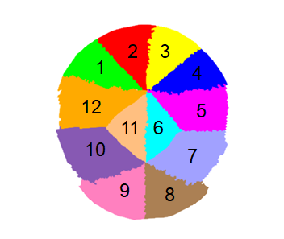

```r
# Include diagram from Porras paper
knitr::include_graphics(here::here("../Literature/Colorado/Region_Diagram.png"))
```

```r
# Manually define center points of regions
brain_points <- tribble(
  ~region, ~x, ~y,
  1, 1, 7,
  2, 2, 8,
  3, 3, 8,
  4, 4, 7,
  5, 4, 5,
  6, 3, 4,
  7, 4, 3,
  8, 3, 1,
  9, 2, 1,
  10, 1, 3,
  11, 2, 4,
  12, 1, 5
) %>%
  st_as_sf(coords = c("x", "y"), remove = F)

# Create nearest-neighbor regions around these points
g = st_combine(st_geometry(brain_points)) # make multipoint
v = st_voronoi(g)
v = st_collection_extract(v)

# Add region numbers
brain_shapes <- v[unlist(st_intersects(brain_points, v))] %>%
  st_as_sf() %>%
  mutate(region_num = 1:n())

# Create circle around whole shape
brain_circle <- tibble(x = 2.5, y = 4.5) %>%
  st_as_sf(coords = c("x", "y")) %>%
  st_buffer(4.5)

# Crop nearest neighbor regions to circle
brain_shapes <- st_intersection(brain_shapes, brain_circle)
```

Next, we visualize the estimated volume patterns corresponding to each suture fusion type on a map of the brain regions.

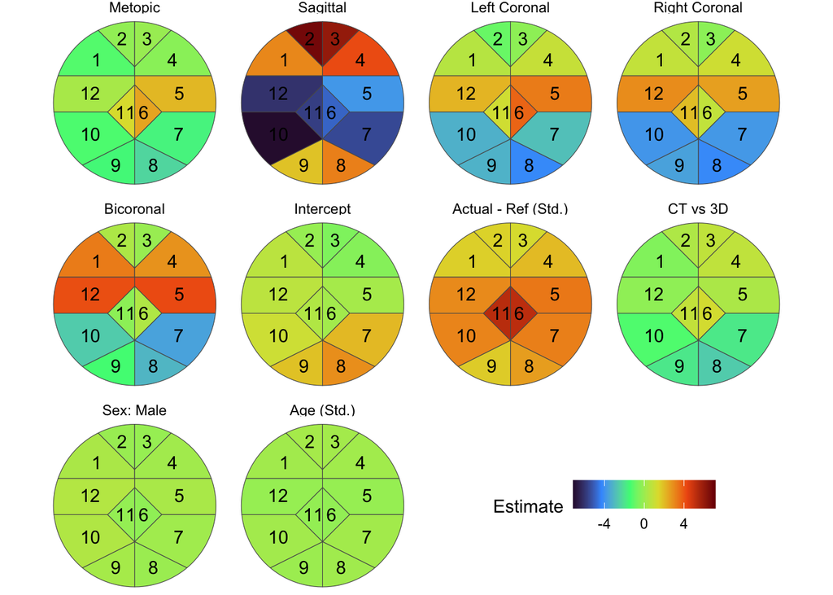

```r
# Extract and clean coefficients and names
reg_coeffs <- coeff_tbl %>%
  mutate(var_clean = str_remove_all(term, "_fused") %>%
           str_replace_all("_", " ") %>%
           str_remove_all("\\(|\\)") %>%
           str_to_title()) %>%
  mutate(var_clean = case_match(var_clean,
                                "Vol Dev Head Std" ~ "Actual - Ref (Std.)",
                                "Image Typect" ~ "CT vs 3D",
                                "Pt Sexmale" ~ "Sex: Male",
                                "Age Std" ~ "Age (Std.)",
                                .default = var_clean)) %>%
  mutate(var_clean = fct_inorder(var_clean)) %>%
  left_join(brain_shapes) %>%
  st_as_sf()

# Filter out bicoronal interaction term
reg_coeffs %<>%
  filter(!term %in% c("left_coronal_fused:right_coronal_fused"))

# Identify suture vs demographics
reg_coeffs %<>%
  mutate(is_suture = if_else(str_detect(term, "fused|bicoronal"), 1, 0))

# Plot coefficients on brain shape
coeff_plot_all0 <- ggplot() +
  geom_sf(data = reg_coeffs, aes(fill = estimate)) +
  geom_sf_text(data = st_centroid(reg_coeffs), aes(label = region_num)) +
  facet_wrap(~var_clean, nrow = 3) +
  scale_fill_viridis_c(option = "turbo",
                       limits = (c(-1, 1) * max(abs(reg_coeffs$estimate)))) +
  labs(x = "", y = "", fill = "Estimate") +
  theme_void() +
  theme(legend.direction = "horizontal")

coeff_plot_all <- shift_legend2(coeff_plot_all0)
```

```r
ggsave(paste0(IMAGES_FOLDER, "/coeff_plot_all.png"),
       coeff_plot_all,
       width = 5, height = 4, units = "in")
```

# Longitudinal Predictive Models

For our second aim, we design longitudinal predictive models to estimate the volumetric deviations a patient will develop in the future. We use leave-one-patient-out cross-validation to evaluate the performance of these models.

## Longitudinal Data

First, we create a new version of the data, including information from previous visits. All images taken of patients above 1 year old are excluded, as well as images without sex or age provided. Further, patients with only one image are omitted from this analysis. From each of the remaining patients, the second image taken is retained. Finally, since performance is evaluated using cross-validation, we exclude the single patient with a left coronal suture fusion remaining in the data.

The following longitudinal measures are calculated: time between the first and second image, total reference volume deviation in the first image, and regional volume deviation in the first image for each of the 12 regions.

One of the longitudinal predictive models estimates the effect of previous regional volume deviations on predicted future outcomes using all regions together. For this model, we create a wider data set with a region indicator column and different columns for each region-covariate interaction.

```r
# Create new data with previous values for cross-validated model
cranio_cv <- cranio_sub %>%
  # Enforce order of patient IDs
  arrange(uid, age) %>%
  group_by(uid) %>%
  mutate(pt_visits = n(),
         visit = 1:n(),
         across(c(age, vol_dev_head, matches("reg_")),
                .fns = list("prev" = ~lag(., 1),
                            "diff" = ~ . - lag(., 1)))) %>%
  ungroup() %>%
  mutate(across(c(vol_dev_head, age),
                ~ ( . - cranio_scale[[paste0(cur_column(), "_mean")]][1]) /
                  cranio_scale[[paste0(cur_column(), "_sd")]][1],
                .names = "{.col}_std"))

# Keep 2nd visit for each patient
cranio_cv_mult <- cranio_cv %>%
  filter(visit == 2) %>%
  # Exclude only observation of their suture type
  group_by(suture_type) %>%
  mutate(n_obs = n()) %>%
  ungroup() %>%
  filter(n_obs > 1) %>%
  select(-n_obs) %>%
  # Code suture type as factor based on frequency
  mutate(suture_type_cln = str_replace_all(suture_type, "_", " ") %>%
           str_to_title(),
         suture_type = fct_infreq(suture_type),
         suture_type_cln = fct_infreq(suture_type_cln))

# Create wider data with interactions between covariates and regions
cranio_cv_comb <- cranio_cv_mult %>%
  pivot_longer(cols = starts_with("reg_"),
               names_pattern = "(reg_[0-9]+)_(.*)",
               names_to = c("region", ".value")) %>%
  mutate(image_type = as.numeric(image_type == "CT"),
         pt_sex = as.numeric(pt_sex == "Male"),
         region2 = region) %>%
  pivot_wider(names_from = region,
              values_from = c(matches("fused"),
                              image_type, pt_sex, age_std, vol_dev_head_prev),
              names_glue = "{region}_{.value}",
              values_fill = 0) %>%
  select(uid, age, region = region2,
         matches("reg_"), vol_dev_prev, vol_dev, age_diff) %>%
  select(-matches("lambdoid"))
```

## Longitudinal Data Summaries

We summarize this subset to compare the characteristics of infants with longitudinal data in the first year to the less restrictive previous sample.

```r
# Keep all images from patients with multiple visits

cranio_cv_longit <- cranio_cv %>%
  filter(pt_visits > 1)

# Summarize counts in multiple visit data
ar_summ <- cranio_cv_longit %>%
  summarize("Rows" = n(),
            "Unique Pictures" = n_distinct(image_identifier),
            "Unique Patients" = n_distinct(uid)) %>%
  pivot_longer(everything(), names_to = "  ", values_to = " ")

kable(ar_summ, caption = "Repeat Visits Data") %>%
  kable_styling(full_width = F)
```

Repeat Visits Data

| Rows | 191 |
| --- | --- |
| Unique Pictures | 191 |
| Unique Patients | 86 |

```r
# Sex
summ_gender_mult <- cranio_cv_longit %>%
  group_by(pt_sex) %>%
  summarize(n = n_distinct(uid)) %>%
  ungroup() %>%
  adorn_totals("row")

kbl(summ_gender_mult, caption = "Longitudinal Patients by Gender") %>% kable_styling(full_width = F)
```

Longitudinal Patients by Gender

| pt_sex | n |
| --- | --- |
| Female | 24 |
| Male | 62 |
| Total | 86 |

```r
# Age
summ_age_cv <- cranio_cv_longit %>%
  filter(visit == 1) %>%
  summarize(age_min = min(age),
            age_med = median(age),
            age_max = max(age)) %>%
  ungroup() %>%
  mutate(across(everything(),
                ~. / 30))

kbl(summ_age_cv, caption = "Longitudinal Patients Age Distibution") %>% kable_styling(full_width = F)
```

Longitudinal Patients Age Distibution

| age_min | age_med | age_max |
| --- | --- | --- |
| 0.0333333 | 3.866667 | 10.36667 |

```r
# Pics per patient
summ_pics_cv <- cranio_cv_longit %>%
  summarize(pics_min = min(pt_visits),
            pics_med = median(pt_visits),
            pics_max = max(pt_visits)) %>%
  ungroup()

kbl(summ_pics_cv, caption = "Longitudinal Patients Pictures Distibution") %>% kable_styling(full_width = F)
```

Longitudinal Patients Pictures Distibution

| pics_min | pics_med | pics_max |
| --- | --- | --- |
| 2 | 2 | 5 |

```r
# Time between
summ_betw_cv <- cranio_cv_mult %>%
  summarize(time_min = min(age_diff, na.rm = T),
            time_med = median(age_diff, na.rm = T),
            time_max = max(age_diff, na.rm = T)) %>%
  ungroup() %>%
  mutate(across(everything(),
                ~. / 30))

kbl(summ_betw_cv, caption = "Longitudinal Patients Interval Distibution") %>% kable_styling(full_width = F)
```

Longitudinal Patients Interval Distibution

| time_min | time_med | time_max |
| --- | --- | --- |
| 0.0333333 | 1.866667 | 8.833333 |

```r
# Summarize suture types in multiple visit data
sut_ar <- cranio_cv_mult %>%
  group_by(suture_type) %>%
  summarize(pics = n(),
            patients = n_distinct(uid)) %>%
  ungroup() %>%
  arrange(desc(pics)) %>%
  mutate(pats_included = if_else(suture_type %in% c("multiple", "right_lambdoid", "left_lambdoid"), 0, patients),
         pct_pats = scales::label_percent(accuracy = 0.1)(patients / sum(patients)),
         pct_included = scales::label_percent(accuracy = 0.1)(pats_included / sum(pats_included))) %>%
  adorn_totals("row") %>%
  select(-pats_included)

sut_kable_ar <- kable(sut_ar, caption = "Sutures: Predictive Data", digits = 2,
      col.names = c("Suture Type", "Pictures", "Patients", "% of Patients", "% of Included")) %>%
  kable_styling(full_width = F)

sut_kable_ar
```

Sutures: Predictive Data

Suture Type

Pictures

Patients

% of Patients

% of Included

sagittal

55

55

64.7%

64.7%

metopic

20

20

23.5%

23.5%

right_coronal

7

7

8.2%

8.2%

bicoronal

3

3

3.5%

3.5%

Total

85

85

```r
label(cranio_cv_mult$image_type) <- "Image Type"
label(cranio_cv_mult$pt_sex) <- "Sex"
label(cranio_cv_mult$pt_race) <- "Race"
label(cranio_cv_mult$pt_ethnicity) <- "Ethnicity"
label(cranio_cv_mult$age) <- "Age"
label(cranio_cv_mult$head_vol) <- "Overall Head Vol. (mL)"
label(cranio_cv_mult$ref_head_vol) <- "Reference Head Vol. (mL)"

# Create table 1
demo_table_ar <- table1::table1(~
                               image_type + pt_sex + pt_race + pt_ethnicity +
                               age + head_vol +
                               ref_head_vol | suture_type_cln,
                             data = cranio_cv_mult)

demo_table_ar_l <- t1kable(demo_table_ar,
                        format = "latex",
                        booktabs = T,
                        label = "t1ar") %>%
  kable_styling(full_width = F, latex_options = "hold_position")

demo_table_ar
```

|  | Sagittal (N=55) | Metopic (N=20) | Right Coronal (N=7) | Bicoronal (N=3) | Overall (N=85) |
| --- | --- | --- | --- | --- | --- |
| Image Type |  |  |  |  |  |
| 3D photo | 43 (78.2%) | 17 (85.0%) | 6 (85.7%) | 1 (33.3%) | 67 (78.8%) |
| CT | 12 (21.8%) | 3 (15.0%) | 1 (14.3%) | 2 (66.7%) | 18 (21.2%) |
| Sex |  |  |  |  |  |
| Female | 13 (23.6%) | 4 (20.0%) | 5 (71.4%) | 1 (33.3%) | 23 (27.1%) |
| Male | 42 (76.4%) | 16 (80.0%) | 2 (28.6%) | 2 (66.7%) | 62 (72.9%) |
| Race |  |  |  |  |  |
| African or African American | 1 (1.8%) | 0 (0%) | 1 (14.3%) | 0 (0%) | 2 (2.4%) |
| American Indian or Alaska Native | 2 (3.6%) | 0 (0%) | 0 (0%) | 0 (0%) | 2 (2.4%) |
| Asian | 6 (10.9%) | 3 (15.0%) | 0 (0%) | 1 (33.3%) | 10 (11.8%) |
| Caucasian | 36 (65.5%) | 10 (50.0%) | 5 (71.4%) | 2 (66.7%) | 53 (62.4%) |
| Missing | 10 (18.2%) | 7 (35.0%) | 1 (14.3%) | 0 (0%) | 18 (21.2%) |
| Ethnicity |  |  |  |  |  |
| Hispanic or Latino | 17 (30.9%) | 8 (40.0%) | 3 (42.9%) | 1 (33.3%) | 29 (34.1%) |
| Not Hispanic or Latino | 37 (67.3%) | 12 (60.0%) | 4 (57.1%) | 2 (66.7%) | 55 (64.7%) |
| Missing | 1 (1.8%) | 0 (0%) | 0 (0%) | 0 (0%) | 1 (1.2%) |
| Age |  |  |  |  |  |
| Mean (SD) | 171 (79.8) | 222 (80.1) | 206 (61.3) | 181 (160) | 186 (83.2) |
| Median [Min, Max] | 154 [48.0, 360] | 218 [88.0, 340] | 199 [131, 274] | 184 [20.0, 340] | 181 [20.0, 360] |
| Overall Head Vol. (mL) |  |  |  |  |  |
| Mean (SD) | 714 (173) | 847 (174) | 692 (144) | 718 (247) | 744 (180) |
| Median [Min, Max] | 689 [382, 1130] | 797 [591, 1170] | 623 [599, 1000] | 762 [451, 939] | 727 [382, 1170] |
| Reference Head Vol. (mL) |  |  |  |  |  |
| Mean (SD) | 697 (157) | 817 (149) | 677 (124) | 684 (239) | 723 (162) |
| Median [Min, Max] | 685 [376, 1050] | 792 [570, 1060] | 611 [591, 943] | 731 [425, 896] | 716 [376, 1060] |

## CV Predictions

The first three models are estimated separately on each of the 12 regions. The fourth model estimates a predictive spline using all regions together, but other covariates are estimated independently for the 12 regions. We run a loop over all of the patients included in this sample: each of the four models is estimated while excluding one patient, and then each model is used to predict the excluded patient’s regional volume deviations in their second visit.

```r
# Define formula for combined spline model
reg_form_combo <- formula(
    paste0("vol_dev ~ 0 + te(age_diff, vol_dev_prev) + ",
           paste(names(cranio_cv_comb %>%
                         select(matches("reg_"))),
                 collapse = " + "), " + ",
           paste(paste0("reg_", 1:12,
                        "_left_coronal_fused * reg_", 1:12,
                        "_right_coronal_fused"), collapse = " + ")
    ))

### Initialize loop

# Save set of patients with multiple visits
subj_ids_mult <- unique(cranio_cv_mult$uid)

# Count patients with multiple visits
n_subj_mult <- length(subj_ids_mult)

# - Mean Sq Pred Error
# - Prediction plots (brain shape for all 88)

# Initialize results data
CV_results <- tibble(NULL)

subj_i <- 1
for(subj_i in 1:n_subj_mult){

  # Pull current subject to be left out
  cur_subj <- subj_ids_mult[subj_i]

  # Drop subject from only repeat (2nd) visits
  cranio_cv_mult_drop_i <- cranio_cv_mult %>%
    filter(uid != cur_subj)

  # Drop subject for combined model data
  cranio_cv_comb_drop_i <- cranio_cv_comb %>%
    filter(uid != cur_subj)

  # Keep separate data of dropped subject
  cranio_cv_mult_i <- cranio_cv_mult %>%
    filter(uid == cur_subj)

  # Keep separate combined data of dropped subject
  cranio_cv_comb_i <- cranio_cv_comb %>%
    filter(uid == cur_subj)

  ### Fit models:

  # 1) Data excluding first / only visits (models relying on previous visits)
  rpt_pts_models_drop_i <- cranio_cv_mult_drop_i %>%
    pivot_longer(cols = starts_with("reg_"),
                 names_pattern = "(reg_[0-9]+)_(.*)",
                 names_to = c("region", ".value")) %>%
    group_by(region) %>%
    nest() %>%
    mutate(
      simple_rpt_model = map(data,
                             ~lm(vol_dev ~ 0 +
                                   metopic_fused + sagittal_fused +
                                   left_coronal_fused + right_coronal_fused +
                                   right_coronal_fused * left_coronal_fused +
                                   image_type + pt_sex + age_std,
                                 data = .x)),
      # Linear model using previous observations for region and overall
      prev_model = map(data,
                       ~lm(vol_dev ~ 0 +
                             metopic_fused + sagittal_fused +
                             left_coronal_fused + right_coronal_fused +
                             right_coronal_fused * left_coronal_fused +
                             image_type + pt_sex + age_std +
                             vol_dev_head_prev + vol_dev_prev,
                           data = .x)),
      # GAM using linear previous overall and surface of previous region
      te_model = map(data,
                     ~mgcv::gam(vol_dev ~ 0 +
                                  metopic_fused + sagittal_fused +
                                  left_coronal_fused + right_coronal_fused +
                                  right_coronal_fused * left_coronal_fused +
                                  image_type + pt_sex + age_std +
                                  vol_dev_head_prev +
                                  te(age_diff, vol_dev_prev),
                                data = .x))
    )

  # 2) "Combined" data: excluding first / only visits, with region interactions
  comb_model_drop_i <- mgcv::gam(reg_form_combo,
                                 data = cranio_cv_comb_drop_i)

  # Get region predictions for excluded observation
  region_models_pred <- cranio_cv_mult_i %>%
    pivot_longer(cols = starts_with("reg_"),
                 names_pattern = "(reg_[0-9]+)_(.*)",
                 names_to = c("region", ".value")) %>%
    group_by(region) %>%
    nest(.key = "new_sample") %>%
    # Merge models estimated without observation
    left_join(rpt_pts_models_drop_i, join_by(region)) %>%
    mutate(simple_rpt_pred = map2_dbl(simple_rpt_model, new_sample,
                                      ~predict(.x, newdata = .y)),
           prev_pred = map2_dbl(prev_model, new_sample,
                                ~predict(.x, newdata = .y)),
           te_pred = map2_dbl(te_model, new_sample,
                              ~predict(.x, newdata = .y))) %>%
    hoist(new_sample, "vol_dev") %>%
    hoist(new_sample, "vol_dev_prev")

  # Predict combined model on 1 observation's 12 outcomes
  cranio_cv_comb_i$combo_pred <- predict(comb_model_drop_i,
                                         newdata = cranio_cv_comb_i)

  # Compile original values and predictions from every model
  pred_df_i <- region_models_pred %>%
    select(region, vol_dev, vol_dev_prev, matches("_pred")) %>%
    ungroup() %>%
    # Merge predictions from combined model
    left_join(cranio_cv_comb_i %>%
                select(region, combo_pred),
              join_by(region)) %>%
    # Calculate out of sample accuracy
    mutate(across(matches("_pred"),
                  ~ (vol_dev - .)^2,
                  .names = "{.col}_sqerr"))

  # Add to running total of results
  new_rows <- pred_df_i %>%
    mutate(
      dropped_subject = subj_i,
      dropped_subject_id = cur_subj,
    )

  # Save in full results data
  CV_results <- bind_rows(CV_results, new_rows)
}
```

## CV Prediction Summaries

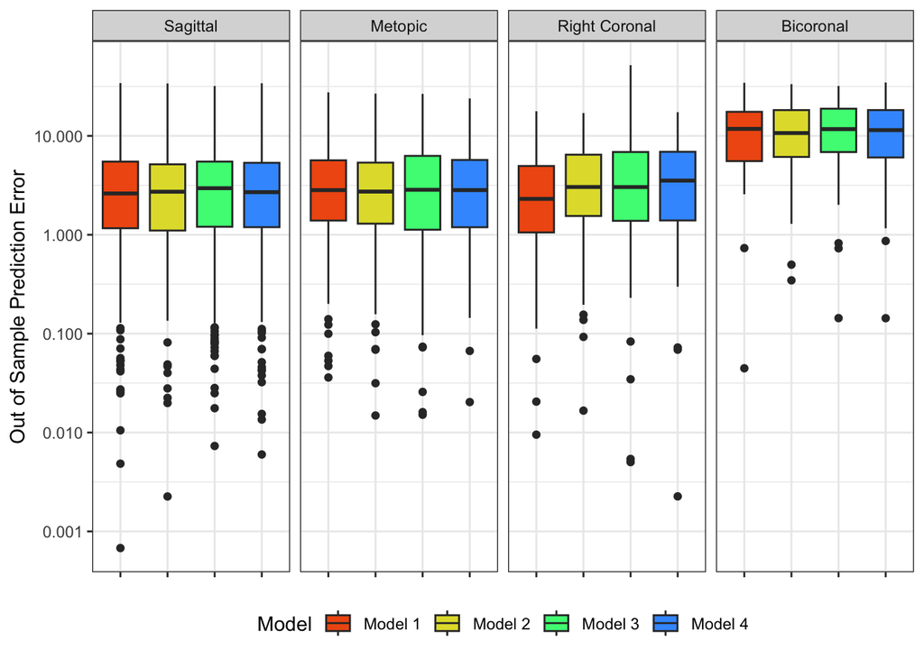

```r
# Merge this info to predictions
cv_out <- CV_results %>%
  left_join(cranio_cv_mult %>% select(uid, suture_type, suture_type_cln),
            by = c("dropped_subject_id" = "uid")) %>%
  mutate(region_num = as.numeric(str_extract(region, "[0-9]+"))) %>%
  # Code suture type as factor based on frequency
  mutate(suture_type_cln = str_replace_all(suture_type, "_", " ") %>%
           str_to_title(),
         suture_type = fct_infreq(suture_type),
         suture_type_cln = fct_infreq(suture_type_cln))

# Pivot so that model name is in a column
cv_out_long <- cv_out %>%
  rename(vol_dev_pred = vol_dev,
         vol_dev_prev_pred = vol_dev_prev) %>%
  pivot_longer(matches("_pred"),
               names_pattern = "(.*)_(pred.*)",
               names_to = c("model", ".value")) %>%
  mutate(pred_abserr = sqrt(pred_sqerr))

# Create pretty names for models
cv_out_long %<>%
  mutate(model = factor(model, levels = c("vol_dev", "vol_dev_prev", "simple_rpt", "prev", "te", "combo"))) %>%
  arrange(model) %>%
  mutate(model_neat = case_match(model,
                                 "vol_dev" ~ "Truth",
                                 "vol_dev_prev" ~ "Prev. Visit",
                                 "simple_rpt" ~ "Model 1",
                                 "prev" ~ "Model 2",
                                 "te" ~ "Model 3",
                                 "combo" ~ "Model 4")) %>%
  mutate(model_neat = fct_inorder(model_neat))

# Visualize (no regions, keep suture together)
suture_box <- cv_out_long %>%
  filter(!model %in% c("vol_dev", "vol_dev_prev", "simple_all")) %>%
  ggplot(aes(x = model_neat,
             y = pred_abserr,
             fill = model_neat)) +
  geom_boxplot() +
  facet_wrap(~suture_type_cln, nrow = 1) +
  scale_y_continuous(transform = "log", breaks = c(10^c(-3:3))) +
  theme_bw() +
  theme(axis.text.x = element_blank(),
        legend.position = "bottom") +
  scale_fill_viridis_d(option = "turbo", begin = 0.2, end = 0.8, direction = -1) +
  labs(x = NULL,
       y = "Out of Sample Prediction Error",
       fill = "Model")

suture_box
```

```r
ggsave(paste0(IMAGES_FOLDER, "/pred_box_oos.png"),
       suture_box,
       width = 6, height = 4, units = "in")
```

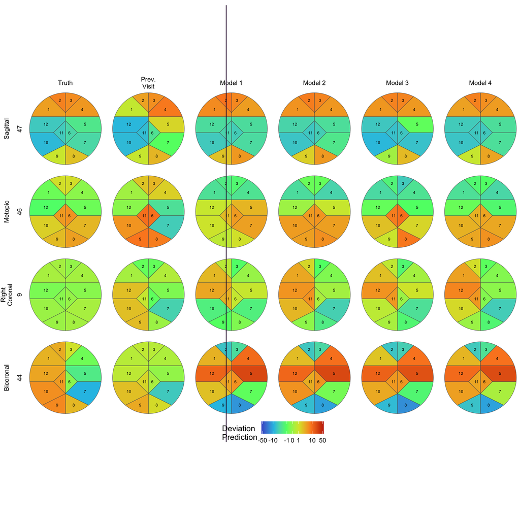

```r
# Identify best and worst predictions for each suture
pred_eg <- cv_out_long %>%
  group_by(dropped_subject, model) %>%
  # Average prediction err across regions for each subject and model
  mutate(subj_model_avg_err = mean(pred_sqerr, na.rm = T)) %>%
  ungroup() %>%
  group_by(suture_type_cln) %>%
  # Maximum and minimum error for each suture type
  mutate(sut_min_err = min(subj_model_avg_err, na.rm = T),
         sut_max_err = max(subj_model_avg_err, na.rm = T)) %>%
  ungroup() %>%
  mutate(is_min = if_else(is.na(subj_model_avg_err) |
                            subj_model_avg_err != sut_min_err, 0, 1),
         is_max = if_else(is.na(subj_model_avg_err) |
                            subj_model_avg_err != sut_max_err, 0, 1)) %>%
  mutate(example_cat = case_when(is_min == 1 ~ "Best",
                                 is_max == 1 ~ "Worst",
                                 T ~ "Neither") %>%
           factor(levels = c("Best", "Worst", "Neither"))) %>%
  # Identify which patient was the min (edit: not the max)
  group_by(dropped_subject) %>%
  filter(sum(is_min) > 0) %>%
  ungroup() %>%
  # Add brain shapes
  left_join(brain_shapes) %>%
  st_as_sf() %>%
  # Identify why this patient was included
  mutate(obs_label = case_when(is_min == 1 ~ paste("Min", suture_type_cln, model),
                               is_max == 1 ~ paste("min", suture_type_cln, model))) %>%
  group_by(dropped_subject) %>%
  mutate(subj_label = paste(unique(na.omit(obs_label)), collapse = "; "))

# Define range of absolute predictions for plots
pred_range <- c(-1, 1) * max(abs(cv_out_long$pred))

# Plot predictions for each model for each of these examples
pred_plot <- ggplot() +
  geom_sf(data = pred_eg, aes(fill = pred)) +
  geom_sf_text(data = st_centroid(pred_eg),
               aes(label = region_num),
               show.legend = F, size = 2) +
  facet_grid(suture_type_cln + dropped_subject ~ model_neat,
             switch = "y",
             labeller = label_wrap_gen(10)) +
  scale_fill_viridis_c(option = "turbo",
                       begin = 0.1, end = 0.9,
                       limits = pred_range,
                       transform = scales::transform_asinh(),
                       breaks = c(-50, -10, -1, 0, 1, 10, 50)) +
  labs(x = NULL, y = NULL,
       fill = "Deviation\nPrediction") +
  theme_void() +
  theme(axis.text = element_blank(),
        axis.ticks = element_blank(),
        strip.text.y = element_text(angle = 90),
        legend.position = "bottom")

pred_plot_ln <- ggdraw(pred_plot) +
  draw_line(x = c(0.435, 0.435), y = c(0.15, 0.99),
            color = viridis::turbo(1))

pred_plot_ln
```

```r
# Save this
ggsave(file = paste0(IMAGES_FOLDER, "/prediction_grid.png"),
       pred_plot_ln,
       height = 3, width = 5, units = "in")

### Also plot a single patient as a descriptive example
pred_eg_lone <- pred_eg %>%
  filter(dropped_subject == pred_eg$dropped_subject[1])

pred_plot_lone <- ggplot() +
  geom_sf(data = pred_eg_lone, aes(fill = pred)) +
  geom_sf_text(data = st_centroid(pred_eg_lone),
               aes(label = region_num)) +
  facet_grid(suture_type + dropped_subject ~ model_neat,
             switch = "y",
             labeller = label_wrap_gen(10)) +
  scale_fill_viridis_c(option = "turbo", limits = pred_range) +
  labs(x = NULL, y = NULL,
       fill = "Prediction", color = "Suture Pred Cat") +
  theme(axis.text = element_blank(),
        axis.ticks = element_blank(),
        strip.text.y = element_text(angle = 90))

ggsave(file = paste0(IMAGES_FOLDER, "/prediction_grid_solo.png"),
       pred_plot_lone,
       height = 4, width = 8, units = "in")
```